# HMM in Marine Sciences: model selection, covariates, hierarchical structures

Marco Gallegos Herrada and Vianey Leos Barajas

```r
library(readr)
library(momentuHMM)
library(ggplot2)
library(dplyr)
library(lubridate)
library(data.tree)
```

**1. Tutorial goals: fit hidden Markov models to accelerometer data in momentuHMM; incorporation of covariates to such models. fit hierarchical Markov models to Depth data;**

# 1 Tutorial objectives

The goal of this tutorial is to explore how to fit hidden Markov models to accelerometer data, the incorporation of covariates on the transition probabilities, and the implementation of hierarchical Markov models to Depth data. For the first two objectives, we will use 4 days of accelerometry data obtained from a free-ranging blacktip reef shark at Palmyra Atoll in the central Pacific Ocean (data taken from Papastamatiou et al. 2015).

**2. Accelerometer data**

**- what it is?**

# 2 Accelerometer data

Accelerometer devices measure up to three axes, which can be described relative to the body of the animal: longitudinal (surge), lateral (sway) and dorsoventral (heave). In each case, means and variances of each of the three axes are used, as well as overall dynamic body acceleration (ODBA), the sum of dynamic body acceleration from the three axes, among others. In the dataset that we’ll be using, the ODBA of the shark was calculated every second.

**- black tip shark data: variables**

The dataset contains information such as the time of the observation, the “water temperature”, “depth” and ODBA. Since one of our goals is to use the time of observations (second of the day) as a covariate, we need to extract this information from the Time variable.

```r
# Reading the data
BlacktipB <- read_delim("BlacktipB_original.txt",
                        delim = "\t", escape_double = FALSE,
                        trim_ws = TRUE)
# Let's transform the date/time info into a proper time format
# In this case we need to extract the second of the day correspondent to each observation
BlacktipB = BlacktipB %>%
  mutate(Time = as.POSIXct(Time,format = "%m/%d/%Y %H:%M")) %>%
  mutate(hour_to_sec =  as.integer(seconds(hm(format(Time, format = "%H:%M")))))
```

[output not shown]

**3. fitting hidden Markov model fot the data**

# 3 Fitting our model

**- Look at data: visualization of ODBA through observed period. Outliers? What do we do with them?**

Looking at the ODBA values through the observed period, we find ODBA is inusually high at some times - usually this measurement is ranging between 0 and 2. Since this could cause a problem at the moment of identifying behaviours, we will take them off from the dataset.

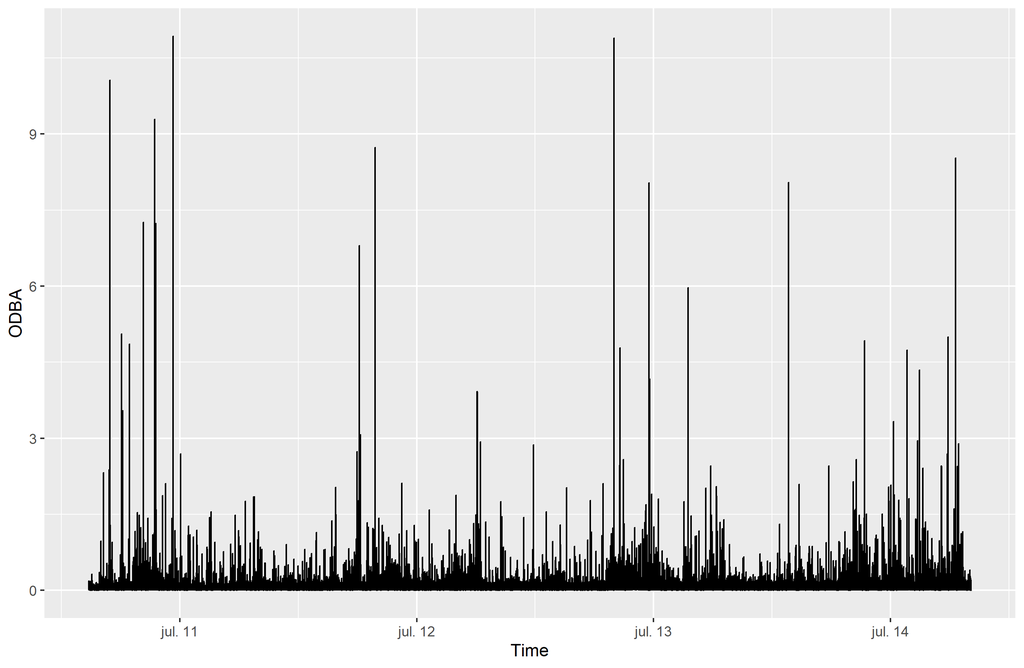

```r
BlacktipB = BlacktipB %>% filter(ODBA <= 2.0)
```

Much better. Now, we are ready to start to look for models for this data!

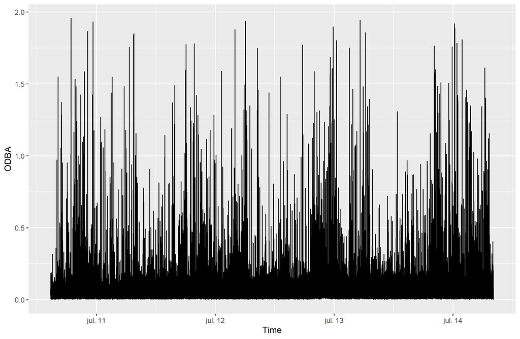

**- histogram of ODBA.** **- Values range. If all positive, what distirbutions can we assign to the data stream ? Gamma distribution would be ok?** **- Can we deduce from it appropiate initial values for our two behavior distributions?**

Given our data, we are interested in finding possible behaviours through the observation process (ODBA). Let’s take a quick look at the histogram of the observations.

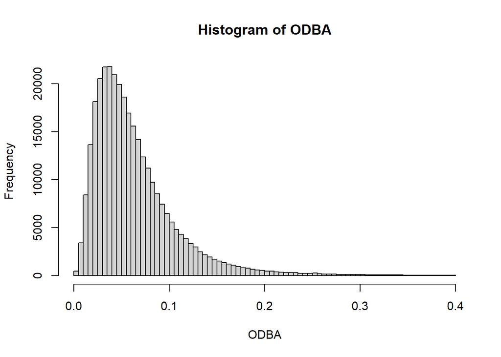

As we have indicated before, the best way to start when fitting a Hidden Markov model is to keep things simple. In this case, we will be considering 2 behavioral states, and no covariates for the transition probability matrix.

For faciliting the search of the 2 state-dependent distributions, we need to provide some initial values so make easier the function to find such densities.

Now that the data is ready for modeling, we chose to fit a 2-stated hidden Markov model. For this purpose, we first need to assign the class `momentuHMMData` to the data in order to be presentable for the functiones related to `momentuHMM`.

```r
BlacktipBData = prepData(BlacktipB,coordNames = NULL,
                   covNames = "hour_to_sec")
```

**- let’s start simple: 2 behaviour states (resting, foraging (?)). No covariates.**

```r
fit1 = fitHMM(BlacktipBData,nbStates=2,dist=list(ODBA="gamma"),Par0 = list(ODBA=c(.1,.3,1,1)))

fit1
```

**- What are the estimated coefficients?**

```
## Value of the maximum log-likelihood: 632931
##
##
## ODBA parameters:
## ----------------
##         state 1    state 2
## mean 0.12024869 0.05092869
## sd   0.07916711 0.02789224
##
## Regression coeffs for the transition probabilities:
## ---------------------------------------------------
##                1 -> 2    2 -> 1
## (Intercept) -2.520214 -3.789739
##
## Transition probability matrix:
## ------------------------------
##            state 1   state 2
## state 1 0.92554680 0.0744532
## state 2 0.02210195 0.9778980
##
## Initial distribution:
## ---------------------
##   state 1   state 2
## 0.4999013 0.5000987
```

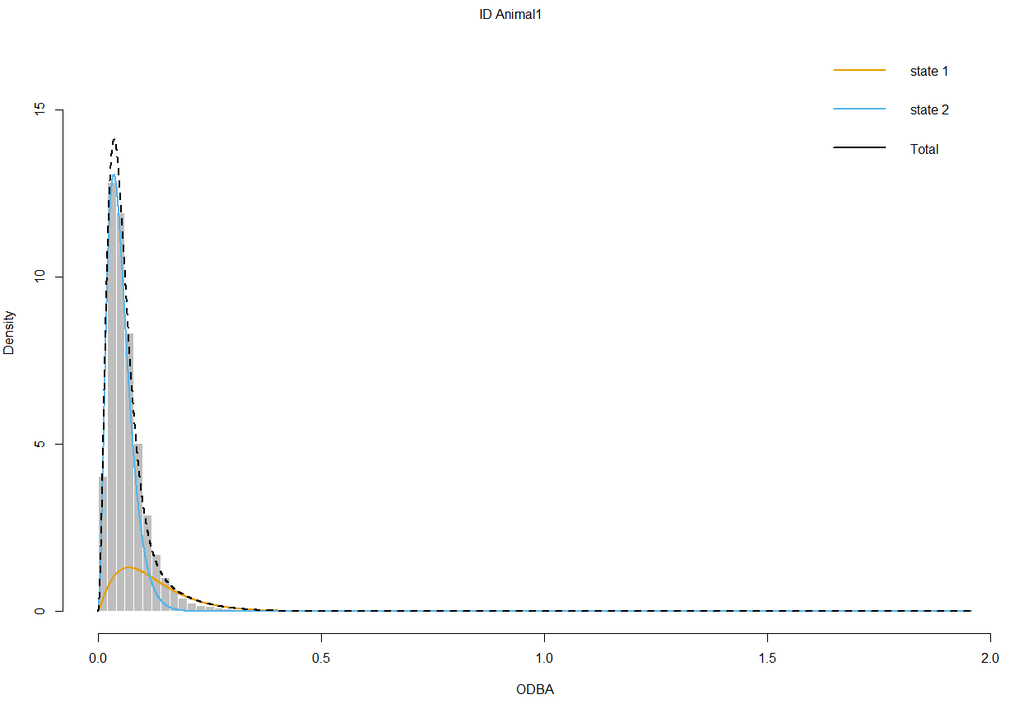

```r
plot(fit1,breaks = 80)
```

**- Let’s include perturbations in the initial values. retryFits is really useful for this. Does the likelihood varies too much when doing this?**

```r
set.seed(147)
fit1_s2 <- fitHMM(BlacktipBData,
                  nbState = 2,
                  dist=list(ODBA="gamma"),
                  Par0 = list(ODBA=c(.1,.3,1,1)),
                  retryFits=10)
```

```r
fit1_s2 <- fitHMM(BlacktipBData,
                  nbState = 2,
                  dist=list(ODBA="gamma"),
                  Par0 = list(ODBA=c(.1,1,1,1)))
```

**- Now that we’ve seen this candidate model seems to be “robust”: Is there any behaviour that predominates over the other? What about the ACF? Did the model captured properly the conditional independence between observations? (Seems to not be the case).**

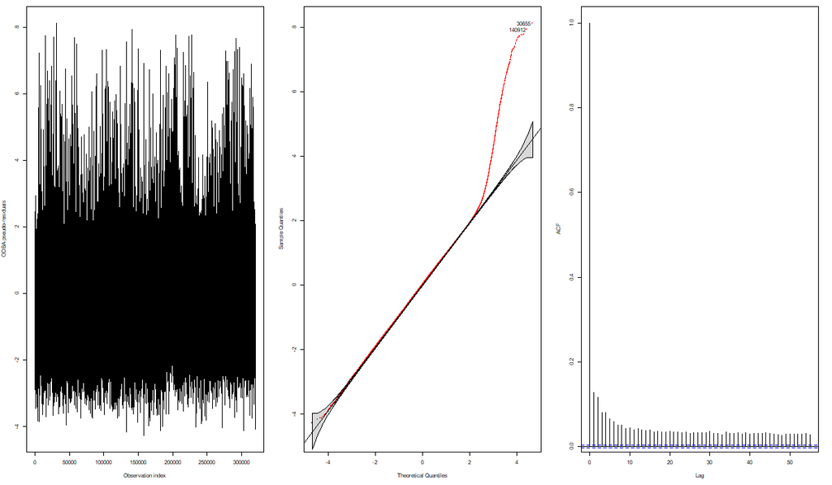

```r
knitr::include_graphics("fit1_PR.png")
```

**- Most likely sequence: What can we infer from this? is there something else we can say from this? According to fitted model, can we see if there is any interesting pattern?**

```r
# identify most likely state using the Viterbi algorithm
BlacktipB$state <- viterbi(fit1)

# proportion of the behaviour states during the observed period
table(BlacktipB$state)/length(BlacktipB$state)
```

```
##
##         1         2
## 0.2088546 0.7911454
```

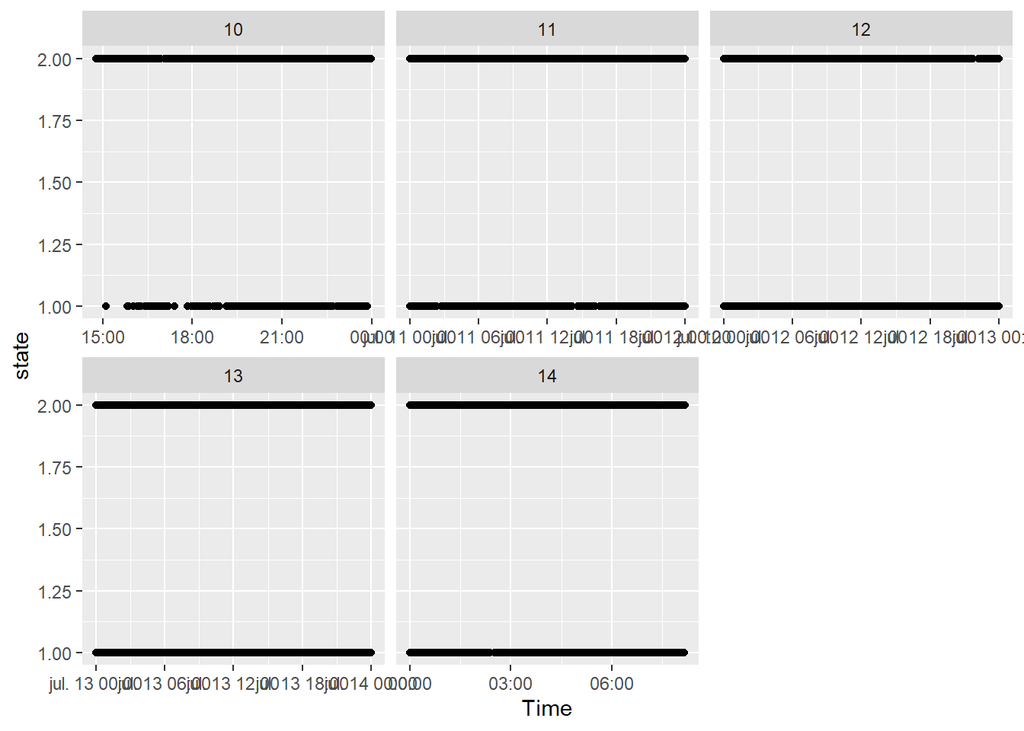

```r
BlacktipB %>% mutate(day = day(Time)) %>% ggplot(aes(Time,state)) + facet_wrap(~day,scales = "free_x") + geom_point()
```

# 4 Incorporating covariates

**- Now let’s incorporate more information: time (second of the day). Let’s include it as a covariate in the transition probabilities.**

As in the article of Vianey, we can incorporate other information that may help explain the values of ODBA. In this case, we are considering the second of the day of every observation. Time of day is represented by two trigonometric functions with period 24 h, $cos(2\pi t/86,400)$ and $sin(2\pi t/86,400)$ (86 400 is the number of seconds in a day). Using the function cosinor, we can convert our data stream to something that is useful for us. As well, we need to provide the formula corresponding to the regression that will be stored in the transition probability values.

```r
# formula corresponding to the regression coefficients for the transition probabilities
formula = ~ cosinor(hour_to_sec, period = 86400)
Par0_fit2 <- getPar0(model=fit1, formula=formula)

fit2 = fitHMM(BlacktipBData,nbStates=2,dist=list(ODBA="gamma"),Par0 = list(ODBA=c(.1,.3,1,1)))

fit2
```

[output not shown]

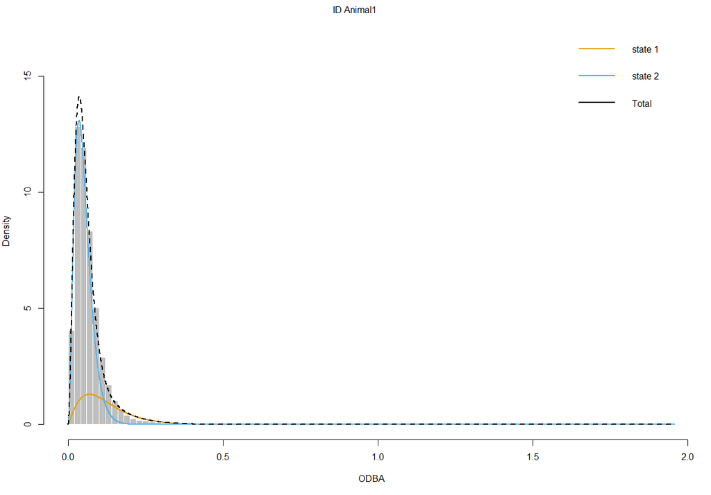

[figure not shown]

```r
plot(fit2)
```

Let’s explore the results.

**- Did the likelihood had a greater value? Did the coefficients vary to much? What about the ACF? Did the autocorrelation decreased with this innovation?**

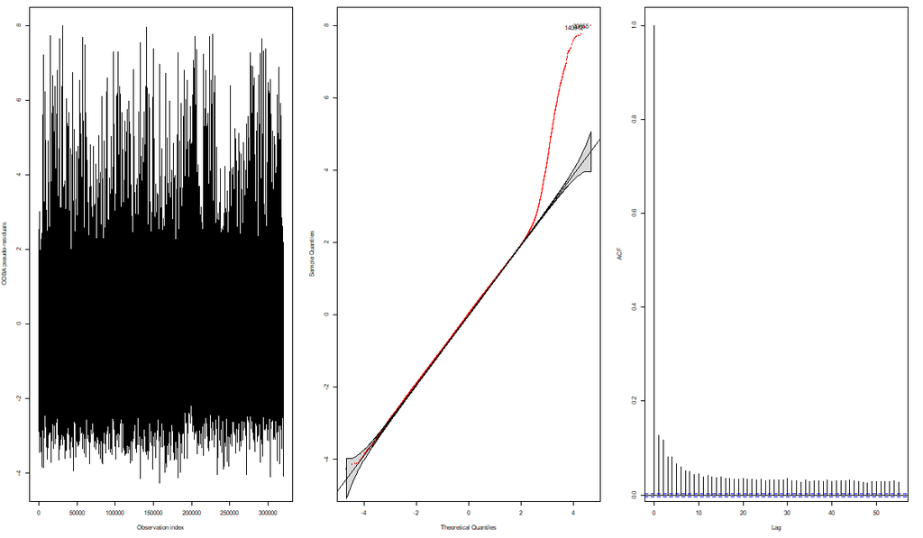

```r
knitr::include_graphics("fit2_PR.png")
```

Akaike information criteria (AIC)

```r
AIC(fit1)
```

```
## [1] -1265848
```

```r
AIC(fit2)
```

```
## [1] -1266372
```

# 5 Depth Data

**4. Depth data:**

**- what it is?** **- tiger shark data: variables. Stream data to consider: absolute change in depth. (`abs_change_depth`)**

```r
# Read the data
tigerShark <- read_csv("tigershark_depthchange10min.csv")
tigerShark = tigerShark %>% mutate(abs_change_depth = abs(Depth - lag(Depth,default = 0)))
head(tigerShark)
```

```
## # A tibble: 6 x 13
##     Date Depth Light ETemp DateTime            HST                  days minutes
##    <dbl> <dbl> <dbl> <dbl> <dttm>              <dttm>              <dbl>   <dbl>
## 1 39882.   4     197  21.6 2009-03-10 01:10:00 2009-03-09 15:10:00     9     910
## 2 39882.   4     200  21.4 2009-03-10 01:20:00 2009-03-09 15:20:00     9     920
## 3 39882.  10     188  21.4 2009-03-10 01:30:00 2009-03-09 15:30:00     9     930
## 4 39882.  17     174  21.3 2009-03-10 01:40:00 2009-03-09 15:40:00     9     940
## 5 39882.  14.5   180  21.4 2009-03-10 01:50:00 2009-03-09 15:50:00     9     950
## 6 39882.  13.5   181  21.2 2009-03-10 02:00:00 2009-03-09 16:00:00     9     960
## # ... with 5 more variables: five <dbl>, ten <dbl>, second <dbl>, depthc <dbl>,
## #   abs_change_depth <dbl>
```

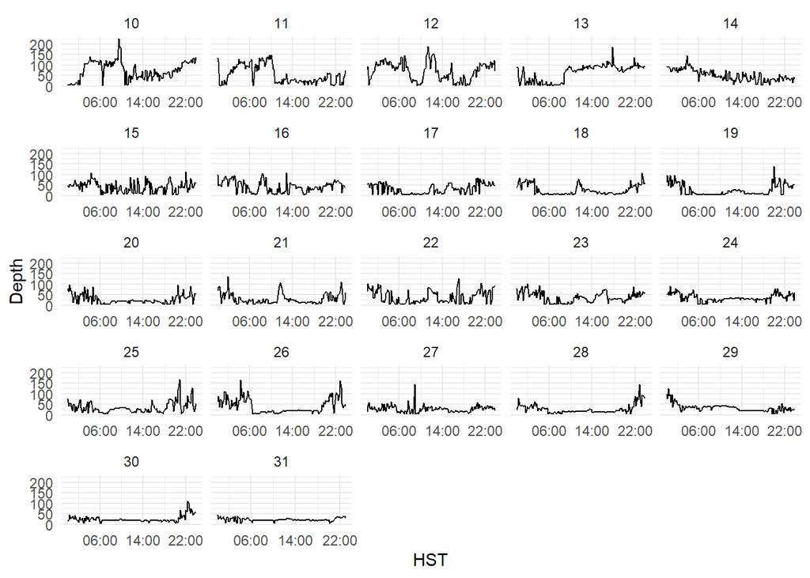

```r
tigerShark %>%
  filter(days != 9) %>%
  ggplot(aes(x=HST,y=Depth)) + facet_wrap(~days,scales = "free_x") + geom_line() +
  scale_x_datetime(breaks= "8 hour", date_labels = "%H:%M") + theme_minimal()
```

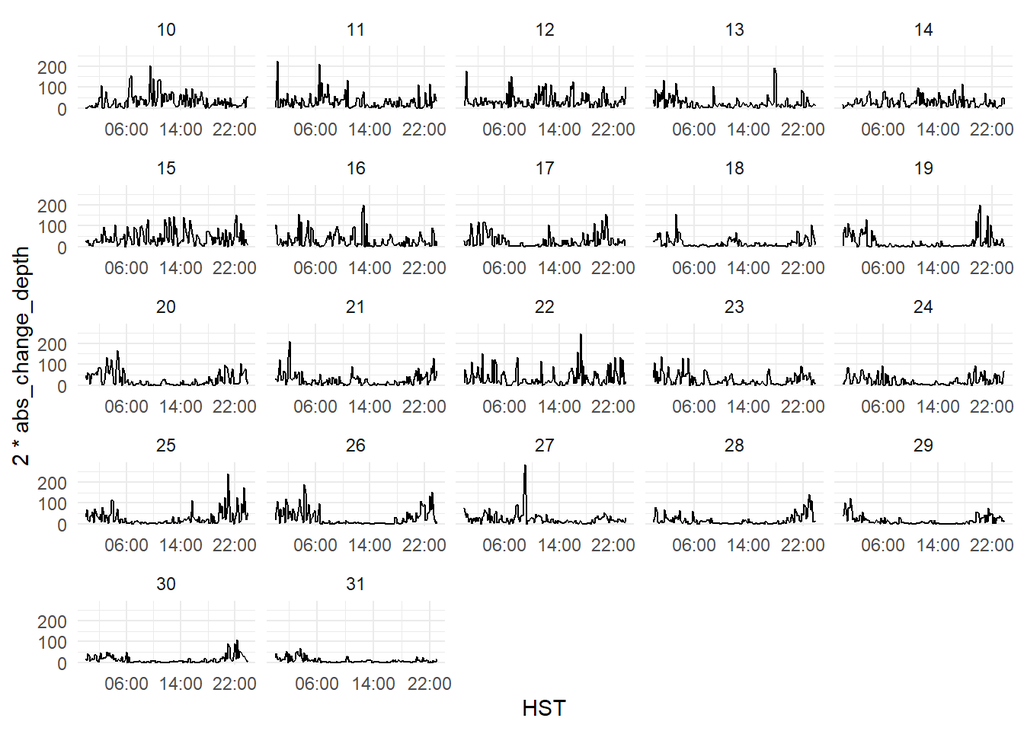

```r
tigerShark %>% filter(days != 9) %>%
  ggplot(aes(x=HST,y=2*abs_change_depth)) + facet_wrap(~days,scales = "free_x") + geom_line() +
  scale_x_datetime(breaks= "8 hour", date_labels = "%H:%M") + theme_minimal()
```

# 6 Hierarchical Hidden Markov models

**5. Hidden Markov models** **- Two possible levels to explain behavior: coarse state-level (day) and fine state-level (10 min).** **- Data processing. We need to include a new column called “level”. With this, momentuHMM will recognize the levels**

```r
days_range = unique(tigerShark$days)
tigerSharkData <- NULL

for(i in days_range){
  coarseInd <- data.frame(tigerShark %>% filter(days == i) %>%
                                   filter(row_number() == 1) %>% select(HST),
                                 days = i,
                                 level=c("1","2i"),
                                 abs_change_depth=NA)
  tmp <- rbind(coarseInd,tigerShark %>% filter(days == i) %>% mutate(level = "2") %>%
                 select(HST,days,level,abs_change_depth))
  tigerSharkData <- rbind(tigerSharkData,tmp)
}

head(tigerSharkData)
```

```
##                   HST days level abs_change_depth
## 1 2009-03-09 15:10:00    9     1               NA
## 2 2009-03-09 15:10:00    9    2i               NA
## 3 2009-03-09 15:10:00    9     2                4
## 4 2009-03-09 15:20:00    9     2                0
## 5 2009-03-09 15:30:00    9     2                6
## 6 2009-03-09 15:40:00    9     2                7
```

```r
tigerSharkData = prepData(tigerSharkData,
                          coordNames = NULL, hierLevels = c("1","2i","2"))


# summarize prepared data
summary(tigerSharkData, dataNames = names(tigerSharkData)[-1])
```

```
## Hierarchical HMM data for 1 individual:
##
## Animal1 -- 3262 observations
##
##
## Data summaries:
##
##       HST                           days    level     abs_change_depth
##  Min.   :2009-03-09 15:10:00   Min.   : 9   1 :  23   Min.   :  0.0
##  1st Qu.:2009-03-15 04:42:30   1st Qu.:15   2i:  23   1st Qu.:  1.5
##  Median :2009-03-20 18:55:00   Median :20   2 :3216   Median :  6.5
##  Mean   :2009-03-20 18:49:24   Mean   :20             Mean   : 12.4
##  3rd Qu.:2009-03-26 08:47:30   3rd Qu.:26             3rd Qu.: 17.5
##  Max.   :2009-03-31 23:00:00   Max.   :31             Max.   :141.0
##                                                       NA's   :46
```

**- How many behavior states (production process) for each possible coarse state value (internal process)? Let’s choose three**

**- Setting everything for the HHMM** **- hierarchy**

```r
### define hierarchical HMM
### states 1-3 = coarse state 1 (nonforaging)
### states 4-6 = coarse state 2 (foraging)
hierStates <- data.tree::Node$new("tiger shark HHMM states")
hierStates$AddChild(name="nontravelling")
hierStates$nontravelling$AddChild(name="nt1", state=1)
hierStates$nontravelling$AddChild(name="nt2", state=2)
hierStates$nontravelling$AddChild(name="nt3", state=3)
hierStates$AddChild(name="travelling")
hierStates$travelling$AddChild(name="t1", state=4)
hierStates$travelling$AddChild(name="t2", state=5)
hierStates$travelling$AddChild(name="t3", state=6)

plot(hierStates)
```

[interactive chart not shown]

```r
#Alternative way for specifying
hierStates <- data.tree::as.Node(list(name="tiger shark HHMM states",
                                      nontravelling=list(nt1=list(state=1),
                                                nt2=list(state=2),
                                                nt3=list(state=3)),
                                      travelling=list(t1=list(state=4),
                                                    t2=list(state=5),
                                                    t3=list(state=6))))
```

**- data stream distribution**

The name for any of the “children” added to a node are user-specified and are akin to the stateNames argument in fitHMM for a standard HMM. While these names are arbitrary, the name and state attributes must be unique.

```r
# data stream distributions
# level 1 = coarse scale (no data streams)
# level 2 = fine scale (dive_duration, maximum_depth, dive_wiggliness)
hierDist <- data.tree::Node$new("tiger shark HHMM dist")
hierDist$AddChild(name="level1")
hierDist$AddChild(name="level2")
hierDist$level2$AddChild(name="abs_change_depth", dist="gamma")
plot(hierDist)
```

[interactive chart not shown]

**- hierarchical t.p.m formula (no covariates)** **- hierarchical initial distribution formula (no covariates)**

[…] did not include any covariates on the t.p.m. or initial distribution for either level of the hierarchy, but, for demonstration purposes, here is how we would use the hierFormula and hierFormulaDelta arguments to specify the t.p.m. and initial distribution formula for each level of the hierarchy in fitHMM:

```r
# define hierarchical t.p.m. formula(s)
hierFormula <- data.tree::Node$new("harbor porpoise HHMM formula")
hierFormula$AddChild(name="level1", formula=~1)
hierFormula$AddChild(name="level2", formula=~1)

# define hierarchical initial distribution formula(s)
hierFormulaDelta <- data.tree::Node$new("harbor porpoise HHMM formulaDelta")
hierFormulaDelta$AddChild(name="level1", formulaDelta=~1)
hierFormulaDelta$AddChild(name="level2", formulaDelta=~1)
```

**- starting values for the behaviour distributions (we will assume the data stream probability distributions do not depend on the coarse-scale state. What does this mean? state 1 and 4 will have the same state-dependent distribution, so the parameters will be equal. Analogous for 2 and 5, and 3 and 6).**

assume the data stream probability distributions do not depend on the coarse-scale state, so we can constrain the state-dependent parameters for states 1 (“nf1”) and 4 (“f1”), states 2 (“nf2”) and 5 (“f2”), and states 3 (“nf3”) and 6 (“f3”) to be equal using the DM argument:

```r
# defining starting values
cd.mu0 = rep(c(5,50,100),hierStates$count)
cd.sigma0 = rep(c(5,15,40),hierStates$count)
cd.pi0 = rep(c(0.2,0.01,0.01),hierStates$count)

Par0 = list(abs_change_depth = c(cd.mu0,cd.sigma0,cd.pi0))

nbStates <- length(hierStates$Get("state",filterFun=data.tree::isLeaf))
```

```r
# constrain fine-scale data stream distributions to be same
cd_DM <- matrix(cbind(kronecker(c(1,1,0,0,0,0),diag(3)),
                      kronecker(c(0,0,1,1,0,0),diag(3)),
                      kronecker(c(0,0,0,0,1,1),diag(3))),
                nrow=nbStates*3,
                ncol=9,
                dimnames=list(c(paste0("mean_",1:nbStates),
                                paste0("sd_",1:nbStates),
                                paste0("zeromass_",1:nbStates)),
                              paste0(rep(c("mean","sd","zeromass"),each=3),
                                     c("_14:(Intercept)",
                                       "_25:(Intercept)",
                                       "_36:(Intercept)"))))
DM = list(abs_change_depth = cd_DM)
```

```r
# get initial parameter values for data stream probability distributions
Par <- getParDM(tigerSharkData,hierStates=hierStates,hierDist=hierDist,
                Par=Par0,DM=DM)

# check hierarchical model specification and parameters
checkPar0(tigerSharkData,hierStates=hierStates,hierDist=hierDist,Par0=Par,
          hierFormula=hierFormula,hierFormulaDelta=hierFormulaDelta,
          DM=DM)
```

```
##
## Regression coeffs for abs_change_depth parameters:
## --------------------------------------------------
##      mean_14:(Intercept) mean_25:(Intercept) mean_36:(Intercept)
## [1,]            1.609438            3.912023             4.60517
##      sd_14:(Intercept) sd_25:(Intercept) sd_36:(Intercept)
## [1,]          1.609438           2.70805          3.688879
##      zeromass_14:(Intercept) zeromass_25:(Intercept) zeromass_36:(Intercept)
## [1,]               -1.386294                -4.59512                -4.59512
##
## ----------------------------------------------------------
## Regression coeffs for the transition probabilities (beta):
## ----------------------------------------------------------
## -------------------------  level1  -----------------------
##                       1 -> 4 4 -> 1
## I((level == "1") * 1)      1      2
##
## -------------------------  level2  -----------------------
##                       1 -> 2 1 -> 3 2 -> 2 2 -> 3 3 -> 2 3 -> 3
## I((level == "2") * 1)      1      2      3      4      5      6
##
##                       4 -> 5 4 -> 6 5 -> 5 5 -> 6 6 -> 5 6 -> 6
## I((level == "2") * 1)      1      2      3      4      5      6
##
## ----------------------------------------------------------
##
## ----------------------------------------------------------
## Regression coeffs for the initial distribution (delta):
## ----------------------------------------------------------
## ------------------------  level1  ------------------------
##             state 4
## (Intercept)       1
##
## ------------------------  level2  ------------------------
##                        state 2 state 3
## I((level == "2i") * 1)       1       2
##
##                        state 5 state 6
## I((level == "2i") * 1)       1       2
##
## ----------------------------------------------------------
```

**- Interpretation of estimated coefficients**

```r
# fit hierarchical HMM
hhmm <- fitHMM(data=tigerSharkData,hierStates=hierStates,hierDist=hierDist,
               #hierFormula=hierFormula,#hierFormulaDelta=hierFormulaDelta,
               Par0=Par,#hierBeta=hierBeta,hierDelta=hierDelta,
               DM=DM,nlmPar=list(hessian=FALSE))
hhmm
```

```
## Value of the maximum log-likelihood: -10961.5
##
##
## abs_change_depth parameters:
## ----------------------------
##                nt1          nt2         nt3        t1           t2          t3
## mean     3.4138952 7.712878e-04 18.48346792 3.4138952 7.712878e-04 18.48346792
## sd       3.2111075 4.312410e+02 16.87558189 3.2111075 4.312410e+02 16.87558189
## zeromass 0.1684493 3.781626e-02  0.01888036 0.1684493 3.781626e-02  0.01888036
##
##
## ---------------------------------------------------------------
## Regression coeffs for the transition probabilities:
## ---------------------------------------------------------------
## --------------------------  level1  ---------------------------
##                           1 -> 4     4 -> 1
## I((level == "1") * 1) -0.9430715 -0.3776745
##
## --------------------------  level2  ---------------------------
##                          1 -> 2    1 -> 3    2 -> 2   2 -> 3    3 -> 2  3 -> 3
## I((level == "2") * 1) -37.81833 -4.086858 -4.199947 4.335918 -23.87418 4.15029
##
##                          4 -> 5    4 -> 6    5 -> 5   5 -> 6    6 -> 5   6 -> 6
## I((level == "2") * 1) -33.12451 -1.429031 -6.869803 4.789274 -31.69066 2.539621
##
## ---------------------------------------------------------------
##
## ---------------------------------------------------------------
## Transition probability matrix (based on mean covariate values):
## ---------------------------------------------------------------
## --------------------------  level1  ---------------------------
##               nontravelling travelling
## nontravelling     0.7197197  0.2802803
## travelling        0.4066879  0.5933121
##
## --------------------------  level2  ---------------------------
##            nt1          nt2        nt3
## nt1 0.98348539 3.702335e-17 0.01651461
## nt2 0.01291822 1.937264e-04 0.98688806
## nt3 0.01551532 6.642600e-13 0.98448468
```

[output cut: 24 more lines]

```
## --------------------------------------------------
## Initial distribution:
## --------------------------------------------------
## --------------------  level1  --------------------
##            nontravelling   travelling
## ID:Animal1     0.9999963 3.710577e-06
##
## --------------------  level2  --------------------
##                      nt1          nt2       nt3
## nontravelling 0.05733259 0.0005215114 0.9421459
##
##                   t1           t2        t3
## travelling 0.1678072 0.0001257684 0.8320671
##
## --------------------------------------------------
```

# 7 Exercises

**4. Exercises** **- Generate new data streams from original datasets (overall mean in different time periods). Does the ACF changes between these data sets? How are they compared to the original data set? What can you say about this?**

- Instead of considering observations every second, create a new data set for 10 sec, another for 30 s and 1 min. Code below will generate such data sets. Fit a basic HMM for the each one of these new datasets. Did the ACF changed? does they seems to not break the conditional independence? (i.e., the ACF values are lower?).

```r
BlacktipB = BlacktipB %>% group_by(Time) %>% mutate(sec = row_number()) %>% ungroup() %>%
  mutate(sec = case_when(hour_to_sec == 53160 ~ as.integer(sec + 55),
                         TRUE ~ sec),
         hour_to_sec = hour_to_sec + sec,
         group_10s = case_when(sec <= 10 ~ 1,
                               10 < sec & sec <= 20 ~ 2,
                               20 < sec & sec <= 30 ~ 3,
                               30 < sec & sec <= 40~ 4,
                               40 < sec & sec <= 50 ~ 5,
                               50 < sec & sec <= 60 ~ 6,
                               TRUE ~ -1),
         group_30s = case_when(sec <= 30 ~ 1,
                               30 < sec & sec <= 60 ~ 2,
                               TRUE ~ -1)) %>%
  group_by(Time,group_10s) %>% mutate(ODBA_mean_10s = mean(ODBA)) %>% ungroup() %>%
  group_by(Time,group_30s) %>% mutate(ODBA_mean_30s = mean(ODBA)) %>% ungroup() %>%
  group_by(Time) %>% mutate(ODBA_mean_60s = mean(ODBA)) %>%
  mutate(hour_to_sec_10s = floor((hour_to_sec-1)/10+1),
         hour_to_sec_30s = floor((hour_to_sec-1)/30+1),
         hour_to_sec_60s = floor((hour_to_sec-1)/60+1))

BlacktipB_10s = BlacktipB %>% group_by(Time,group_10s) %>% filter(row_number() == 1) %>%
  ungroup() %>% select(Time,Depth,ODBA_mean_10s,hour_to_sec_10s)
BlacktipB_30s = BlacktipB %>% group_by(Time,group_30s) %>% filter(row_number() == 1) %>%
  ungroup() %>% select(Time,Depth,ODBA_mean_30s,hour_to_sec_30s)
BlacktipB_60s = BlacktipB %>% group_by(Time) %>% filter(row_number() == 1) %>%
  ungroup() %>% select(Time,Depth,ODBA_mean_60s,hour_to_sec_60s)

BlacktipB = BlacktipB %>% select(Time,Depth,ODBA,hour_to_sec)
```

**- Fit a 3-stated HMM with no covariates and fit another one taking time as a covariate. What happents to the ACF? According to loglikelihood and AIC, which model is better?**

- Reproduce the analysis from the black tip shark data, but now include three states. What about the ACF? Did something change compared to 2-state HMM? Now include hour_to_sec as a covariate and fit a new model. What happen with the AIC values and the loglikelihood? According to these, what seems to be a better model?

# 8 Intended structure of tutorial